# **Used Cars Price Prediction**

## **Problem Definition**

### **The Context:**

- There is a huge demand for used cars in the Indian Market today. As sales of new cars have slowed down in the recent past, the pre-owned car market has continued to grow over the past years and is larger than the new car market now. Cars4U is a budding tech start-up that aims to find footholes in this market.
- In 2018-19, while new car sales were recorded at 3.6 million units, around 4 million second-hand cars were bought and sold. There is a slowdown in new car sales and that could mean that the demand is shifting towards the pre-owned market. In fact, some car sellers replace their old cars with pre-owned cars instead of buying new ones. Unlike new cars, where price and supply are fairly deterministic and managed by OEMs (Original Equipment Manufacturer / except for dealership level discounts which come into play only in the last stage of the customer journey), used cars are very different beasts with huge uncertainty in both pricing and supply. Keeping this in mind, the pricing scheme of these used cars becomes important in order to grow in the market.

### **The objective:**

- Explore and analyze dataset
- Perform Univariate and Bivariate analysis
- Preprocess the data (fixing bad data/outlier treatment).
- Build regression models to predict the prices of used cars.
- Performance evaluation of model by RMSE.
- Generate a set of insights and recommendations that will help the business.

### **The key questions:**

- What Factors Influence Used Car Pricing?
- Does Car Brand Affect Car Price?
- How Does Transmission Type Impact Price?
- Does Location Affect Car Price?
- Is There a Correlation Between Kilometers Driven, Year of Manufacture, and Price?
- How Does Mileage, Engine, and Power Affect Pricing? What's the Impact of Seating Capacity and Fuel Type on Pricing?

### **The problem formulation**:

- We are exploring and processing used car data and will be developing and comparing several models to best predict price given our features.

### **Data Dictionary**

- **S.No.** : Serial Number
- **Name** : Name of the car which includes Brand name and Model name
- **Location** : The location in which the car is being sold or is available for purchase (Cities)
- **Year** : Manufacturing year of the car
- **Kilometers_driven** : The total kilometers driven in the car by the previous owner(s) in KM
- **Fuel_Type** : The type of fuel used by the car (Petrol, Diesel, Electric, CNG, LPG)
- **Transmission** : The type of transmission used by the car (Automatic / Manual)
- **Owner** : Type of ownership
- **Mileage** : The standard mileage offered by the car company in kmpl or km/kg
- **Engine** : The displacement volume of the engine in CC
- **Power** : The maximum power of the engine in bhp
- **Seats** : The number of seats in the car
- **New_Price** : The price of a new car of the same model in INR 100,000
- **Price** : The price of the used car in INR 100,000 (**Target Variable**)

### **Loading libraries**

```python
import pandas as pd
import numpy as np
import matplotlib.pyplot as plt
import seaborn as sns
sns.set_style("darkgrid")
from statsmodels.stats.outliers_influence import variance_inflation_factor
from sklearn.linear_model import LinearRegression
from sklearn.model_selection import train_test_split,cross_val_score
from sklearn.metrics import mean_squared_error
import time
from sklearn.model_selection import train_test_split,GridSearchCV,KFold
from sklearn.metrics import mean_absolute_percentage_error,mean_squared_error
from sklearn.tree import DecisionTreeRegressor
from sklearn.ensemble import RandomForestRegressor
from sklearn.linear_model import Lasso,Ridge
from sklearn import tree
from xgboost import XGBRegressor
from google.colab import drive
import statsmodels.api as sm
from sklearn.preprocessing import StandardScaler
from statsmodels.stats.outliers_influence import variance_inflation_factor
import warnings
warnings.filterwarnings("ignore")
```

### **Let us load the data**

```python
drive.mount('/content/drive/')
df1 = pd.read_csv('/content/drive/MyDrive/used_cars.csv')
df = df1.copy()
```

## Data Overview

```python
df.head()
```

|  | S.No. | Name | Location | Year | Kilometers_Driven | Fuel_Type | Transmission | Owner_Type | Mileage | Engine | Power | Seats | New_price | Price |
| --- | --- | --- | --- | --- | --- | --- | --- | --- | --- | --- | --- | --- | --- | --- |
| 0 | 0 | Maruti Wagon R LXI CNG | Mumbai | 2010 | 72000 | CNG | Manual | First | 26.60 | 998.0 | 58.16 | 5.0 | NaN | 1.75 |
| 1 | 1 | Hyundai Creta 1.6 CRDi SX Option | Pune | 2015 | 41000 | Diesel | Manual | First | 19.67 | 1582.0 | 126.20 | 5.0 | NaN | 12.50 |
| 2 | 2 | Honda Jazz V | Chennai | 2011 | 46000 | Petrol | Manual | First | 18.20 | 1199.0 | 88.70 | 5.0 | 8.61 | 4.50 |
| 3 | 3 | Maruti Ertiga VDI | Chennai | 2012 | 87000 | Diesel | Manual | First | 20.77 | 1248.0 | 88.76 | 7.0 | NaN | 6.00 |
| 4 | 4 | Audi A4 New 2.0 TDI Multitronic | Coimbatore | 2013 | 40670 | Diesel | Automatic | Second | 15.20 | 1968.0 | 140.80 | 5.0 | NaN | 17.74 |

It appears from df.head(), that S.No. is a duplicate of the index. Let's see.

```python
df['S.No.'].nunique()
```

```
7253
```

```python
df.shape[0]
```

```
7253
```

```python
df = df.drop('S.No.',axis=1)
```

#### **Missing and Duplicated data**

```python
df.isnull().sum()
```

```
Name                    0
Location                0
Year                    0
Kilometers_Driven       0
Fuel_Type               0
Transmission            0
Owner_Type              0
Mileage                 2
Engine                 46
Power                 175
Seats                  53
New_price            6247
Price                1234
dtype: int64
```

We can see that that several columns have missing data. 'New Price' is missing 6247 rows.

```python
df['New_price'].isnull().sum()/len(df)
```

```
0.8612987729215497
```

Since 86% of the column is missing, we will go ahead and drop that too.

```python
df = df.drop('New_price',axis=1)
```

**Duplicates**

```python
df[df.duplicated()]
```

|  | Name | Location | Year | Kilometers_Driven | Fuel_Type | Transmission | Owner_Type | Mileage | Engine | Power | Seats | Price |
| --- | --- | --- | --- | --- | --- | --- | --- | --- | --- | --- | --- | --- |
| 6582 | Honda City 1.5 E MT | Mumbai | 2010 | 52000 | Petrol | Manual | First | 17.0 | 1497.0 | 118.0 | 5.0 | NaN |

```python
df = df.drop_duplicates()
```

```python
df.shape
```

```
(7252, 12)
```

## **EDA**

```python
df.columns
```

```
Index(['Name', 'Location', 'Year', 'Kilometers_Driven', 'Fuel_Type',
       'Transmission', 'Owner_Type', 'Mileage', 'Engine', 'Power', 'Seats',
       'Price'],
      dtype='object')
```

```python
#seperating category and numerical columns
cat_cols = ['Location','Fuel_Type','Owner_Type','Seats','Transmission']
num_cols = ['Year', 'Kilometers_Driven','Mileage', 'Engine', 'Power','Price']
```

#### **Univariate Analysis**

```python
df.describe().T
```

|  | count | mean | std | min | 25% | 50% | 75% | max |
| --- | --- | --- | --- | --- | --- | --- | --- | --- |
| Year | 7252.0 | 2013.365830 | 3.254405 | 1996.00 | 2011.00 | 2014.00 | 2016.00 | 2019.00 |
| Kilometers_Driven | 7252.0 | 58699.986900 | 84433.505524 | 171.00 | 34000.00 | 53429.00 | 73000.00 | 6500000.00 |
| Mileage | 7250.0 | 18.141738 | 4.562492 | 0.00 | 15.17 | 18.16 | 21.10 | 33.54 |
| Engine | 7206.0 | 1616.590064 | 595.324779 | 72.00 | 1198.00 | 1493.00 | 1968.00 | 5998.00 |
| Power | 7077.0 | 112.764474 | 53.497297 | 34.20 | 75.00 | 94.00 | 138.10 | 616.00 |
| Seats | 7199.0 | 5.280456 | 0.809327 | 2.00 | 5.00 | 5.00 | 5.00 | 10.00 |
| Price | 6019.0 | 9.479468 | 11.187917 | 0.44 | 3.50 | 5.64 | 9.95 | 160.00 |

- **Year:** The oldest cars were produced in 1996, newest in 2019, mean is 2013.
- **Kilometers_Driven:** Lowest KM driven is 171, highest is 6500000!, average is 58699.
- **Mileage:** The worst mileage is zero!, best is 33.54, average is ~18
- **Engine:** The smallest engine is 72cc, 5998cc is the largest, average is 1616cc.
- **Power:** Lowest bhp is ~34, highest is 616, average is ~112
- **Price:** Lowest used cost is .44 highest is 160, average is ~9.5

**Fixing Kilometers**

```python
df[(df['Kilometers_Driven']==6500000)]
```

|  | Name | Location | Year | Kilometers_Driven | Fuel_Type | Transmission | Owner_Type | Mileage | Engine | Power | Seats | Price |
| --- | --- | --- | --- | --- | --- | --- | --- | --- | --- | --- | --- | --- |
| 2328 | BMW X5 xDrive 30d M Sport | Chennai | 2017 | 6500000 | Diesel | Automatic | First | 15.97 | 2993.0 | 258.0 | 5.0 | 65.0 |

```python
#replacing value with median
condition = (df['Kilometers_Driven']==6500000)
df.loc[condition,'Kilometers_Driven'] = 53416
```

There's only one row with this value, so we will replace it with the median.

**FIxing Mileage**

```python
len(df[(df['Mileage']==0)])
```

```
81
```

There are 81 rows with mileage at 0. Let's replace 0 with NaN for now.

```python
df.loc[df["Mileage"]==0,'Mileage']=np.nan
```

**Price**

```python
df[(df['Price']==160)]
```

|  | Name | Location | Year | Kilometers_Driven | Fuel_Type | Transmission | Owner_Type | Mileage | Engine | Power | Seats | Price |
| --- | --- | --- | --- | --- | --- | --- | --- | --- | --- | --- | --- | --- |
| 4079 | Land Rover Range Rover 3.0 Diesel LWB Vogue | Hyderabad | 2017 | 25000 | Diesel | Automatic | First | 13.33 | 2993.0 | 255.0 | 5.0 | 160.0 |

According to US News Report, on average a 2017 Vogue is going for around 37.5 INR.

```python
#replacing values
condition = (df['Price']==160)
df.loc[condition,'Price'] = 37.5
```

**Numerical Columns**

```python
#function to plot histplot and boxplot on shared axis
def histogram_boxplot(data, feature, figsize=(8,1.5), kde=True,color=None):
    fig, (ax_box, ax_hist) = plt.subplots(2, sharex=True, gridspec_kw={"height_ratios": [0.3, 0.7]}, figsize=figsize)

    sns.histplot(data=data, x=feature, kde=kde, ax=ax_hist,color=color)
    sns.boxplot(data=data, x=feature, ax=ax_box, showmeans=True,color=color)

    # Remove the boxplot x labels
    ax_box.set_xlabel('')
    ax_box.set_ylabel('')

    #removing space between plots
    plt.subplots_adjust(hspace=0)
```

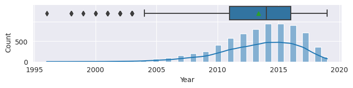

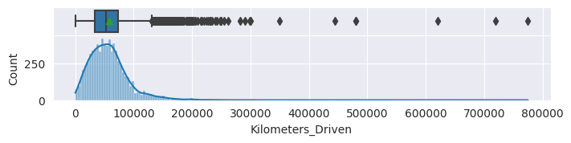

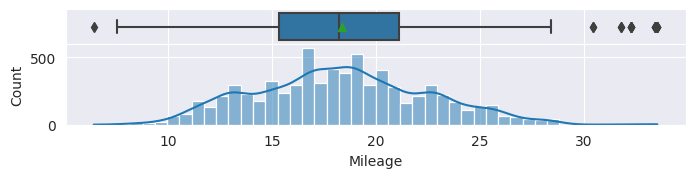

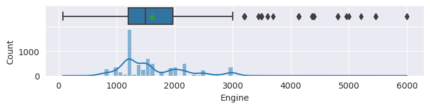

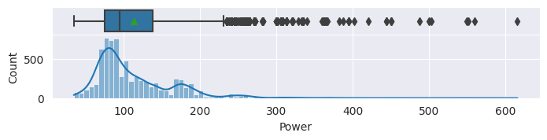

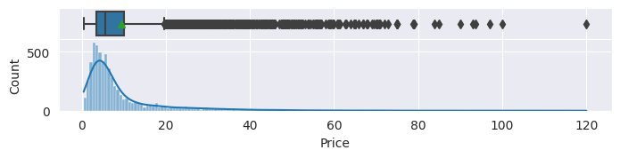

```python
for column in num_cols:
  histogram_boxplot(df, column, figsize=(8,1.5), kde=True,color=None)
```

Categorical Columns

```python
for column in cat_cols:
    print(df[column].value_counts())
    print("~" * 35)
```

```
Mumbai        948
Hyderabad     876
Coimbatore    772
Kochi         772
Pune          765
Delhi         660
Kolkata       654
Chennai       591
Jaipur        499
Bangalore     440
Ahmedabad     275
Name: Location, dtype: int64
~~~~~~~~~~~~~~~~~~~~~~~~~~~~~~~~~~~
Diesel      3852
Petrol      3324
CNG           62
LPG           12
Electric       2
Name: Fuel_Type, dtype: int64
~~~~~~~~~~~~~~~~~~~~~~~~~~~~~~~~~~~
First             5951
Second            1152
Third              137
Fourth & Above      12
Name: Owner_Type, dtype: int64
~~~~~~~~~~~~~~~~~~~~~~~~~~~~~~~~~~~
5.0     6047
7.0      796
8.0      170
4.0      119
6.0       38
2.0       18
10.0       8
9.0        3
Name: Seats, dtype: int64
~~~~~~~~~~~~~~~~~~~~~~~~~~~~~~~~~~~
Manual       5203
Automatic    2049
Name: Transmission, dtype: int64
~~~~~~~~~~~~~~~~~~~~~~~~~~~~~~~~~~~
```

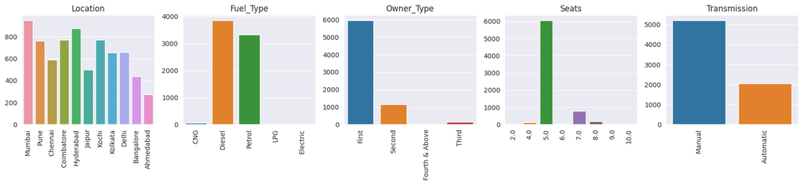

```python
# Create a figure and axis for the subplots
fig, axes = plt.subplots(1, 5, figsize=(17, 4))
# Flatten the 2D array of axes to make it easier to iterate over
axes = axes.flatten()
# Iterate through the categorical columns and plot count plots
for i, cat_col in enumerate(cat_cols):
    sns.countplot(data=df,x=cat_col, ax=axes[i])
    axes[i].set_title(cat_col)
    axes[i].set_xlabel('')
    axes[i].set_ylabel('')
    axes[i].tick_params(axis='x', rotation=90)
# Adjust spacing between subplots
plt.tight_layout();
```

- **Location:** Most cars are located in Mumbai, the least are in Amhedabad.
- **Fuel Type:** Most cars are either Petrol and Diesel
- **Transmission:** There are more manual cars than automatic
- **Owner Type:** Most cars have only had one owner, followed by two owner's.
- **Seats:** Most have 5 seats, followed by 7.

#### **Bivariate Analysis**

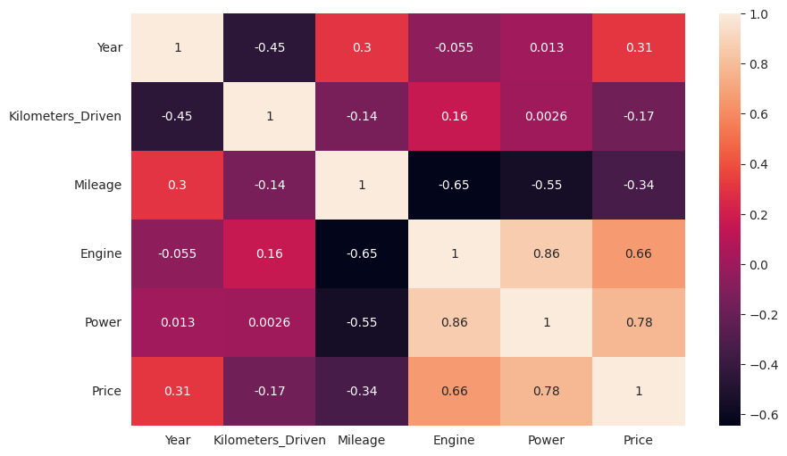

```python
num_df = df[num_cols]
plt.figure(figsize=(10,6))
sns.heatmap(num_df.corr(),annot=True);
```

**Price and Numerical Columns**

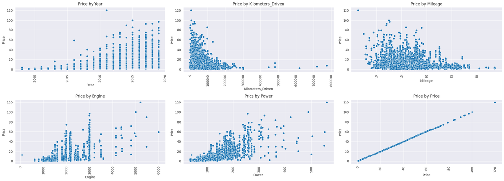

```python
# Create a figure and axis for the subplots
fig, axes = plt.subplots(2, 3, figsize=(22, 8))
# Flatten the 2D array of axes to make it easier to iterate over
axes = axes.flatten()
# Iterate through the categorical columns and plot count plots
for i, num_col in enumerate(num_cols):
    sns.scatterplot(data=df,y='Price', x=num_col, ax=axes[i])
    axes[i].set_ylabel('Price')
    axes[i].set_title(f"Price by {num_col}")
    axes[i].tick_params(axis='x', rotation=90);
# Adjust spacing between subplots
plt.tight_layout();
```

Here we can better see the previously mentioned correlations.

**Price and Categorical Columns**

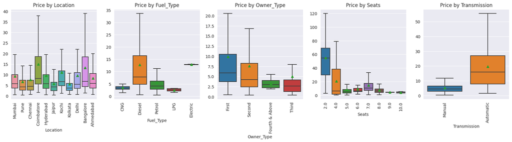

```python
# Create a figure and axis for the subplots
fig, axes = plt.subplots(1, 5, figsize=(22, 4))
# Flatten the 2D array of axes to make it easier to iterate over
axes = axes.flatten()
# Iterate through the categorical columns and plot count plots
for i, cat_col in enumerate(cat_cols):
    sns.boxplot(data=df,y='Price', x=cat_col, ax=axes[i],showmeans=True,showfliers=False)
    axes[i].set_ylabel('')
    axes[i].set_title(f"Price by {cat_col}")
    axes[i].tick_params(axis='x', rotation=90);
```

## **Feature Engineering**

**Name**

```python
df['Name'].nunique()
```

```
2041
```

There are 2041 unique names, which is high for our purposes, but we can see that the make appears to be the first word of the 'Name' and the model is the remainder. Let's split the column after the first space in the text.

```python
df['Name'].sample(20)
```

```
2804                        Maruti Alto 800 2016-2019 VXI
396                               BMW 3 Series 320d Sedan
3125                                Hyundai i10 Sportz AT
1067                             Hyundai Grand i10 Sportz
457                   Audi Q3 35 TDI Quattro Premium Plus
5054                                   Maruti Celerio ZDi
6360                                Honda Amaze S i-Vtech
6473    Mercedes-Benz E-Class 2015-2017 E250 CDI Avant...
753                                   Chevrolet Cruze LTZ
6268                     Hyundai Verna 1.6 SX VTVT (O) AT
6583                                Maruti Swift VDI BSIV
4765                                    Maruti Ertiga VXI
4480                     Hyundai Xcent 1.1 CRDi SX Option
3852                                    BMW 3 Series 320d
3346                     Volkswagen Vento Diesel Highline
3900                                    Maruti Ertiga LXI
3133                               Maruti Swift Dzire VDi
1848                              Fiat Linea T-Jet Active
3468                              Hyundai Grand i10 Magna
1029                 BMW 5 Series 2003-2012 530d Highline
Name: Name, dtype: object
```

```python
# Splitting the column and keeping everything to the left of the first space
df['Make'] = df['Name'].str.split(n=1).str[0].str.title()
```

```python
df['Make'].unique()
```

```
array(['Maruti', 'Hyundai', 'Honda', 'Audi', 'Nissan', 'Toyota',
       'Volkswagen', 'Tata', 'Land', 'Mitsubishi', 'Renault',
       'Mercedes-Benz', 'Bmw', 'Mahindra', 'Ford', 'Porsche', 'Datsun',
       'Jaguar', 'Volvo', 'Chevrolet', 'Skoda', 'Mini', 'Fiat', 'Jeep',
       'Smart', 'Ambassador', 'Isuzu', 'Force', 'Bentley', 'Lamborghini',
       'Hindustan', 'Opelcorsa'], dtype=object)
```

All the returned names are recognizable car manufacturers, besides 'Land'. Lets look into that.

```python
df[df['Name'].str.startswith('Land')].head(3)
```

|  | Name | Location | Year | Kilometers_Driven | Fuel_Type | Transmission | Owner_Type | Mileage | Engine | Power | Seats | Price | Make |
| --- | --- | --- | --- | --- | --- | --- | --- | --- | --- | --- | --- | --- | --- |
| 13 | Land Rover Range Rover 2.2L Pure | Delhi | 2014 | 72000 | Diesel | Automatic | First | 12.7 | 2179.0 | 187.7 | 5.0 | 27.00 | Land |
| 14 | Land Rover Freelander 2 TD4 SE | Pune | 2012 | 85000 | Diesel | Automatic | Second | NaN | 2179.0 | 115.0 | 5.0 | 17.50 | Land |
| 191 | Land Rover Range Rover 2.2L Dynamic | Coimbatore | 2018 | 36091 | Diesel | Automatic | First | 12.7 | 2179.0 | 187.7 | 5.0 | 55.76 | Land |

We can see that 'Land' is actually 'Land Rover'.

```python
land_rover_dict = {'Land':'Land-Rover'}
df['Make'] = df['Make'].replace(land_rover_dict)

df['Make'].unique()
```

```
array(['Maruti', 'Hyundai', 'Honda', 'Audi', 'Nissan', 'Toyota',
       'Volkswagen', 'Tata', 'Land-Rover', 'Mitsubishi', 'Renault',
       'Mercedes-Benz', 'Bmw', 'Mahindra', 'Ford', 'Porsche', 'Datsun',
       'Jaguar', 'Volvo', 'Chevrolet', 'Skoda', 'Mini', 'Fiat', 'Jeep',
       'Smart', 'Ambassador', 'Isuzu', 'Force', 'Bentley', 'Lamborghini',
       'Hindustan', 'Opelcorsa'], dtype=object)
```

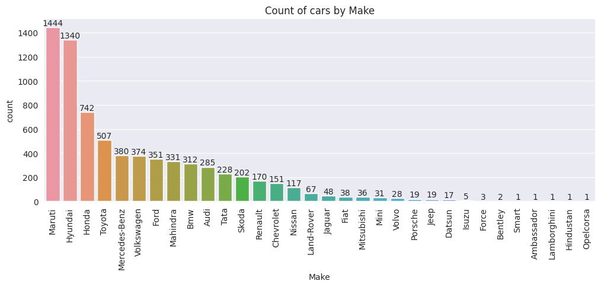

```python
plt.figure(figsize=(12,4))
plt.title('Count of cars by Make')
ax = sns.countplot(x='Make', data = df, order = df['Make'].value_counts().iloc[:50].index)
plt.xticks(rotation=90);
ax.bar_label(ax.containers[0], label_type='edge');
```

We can see that Maruti and Hyundai make up most of the cars. We can see that some makes only have had one car sell.

**Car Make and Price**

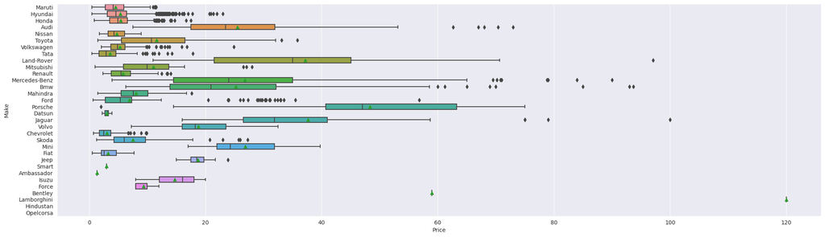

```python
plt.figure(figsize=(25,7))
sns.boxplot(data=df,x='Price', y='Make', showmeans=True,showfliers=True);
```

Let's look into some of the following outliers:

```python
df[(df['Price'] < 4) & (df['Make'] =='Porsche')]
```

|  | Name | Location | Year | Kilometers_Driven | Fuel_Type | Transmission | Owner_Type | Mileage | Engine | Power | Seats | Price | Make |
| --- | --- | --- | --- | --- | --- | --- | --- | --- | --- | --- | --- | --- | --- |
| 3132 | Porsche Cayenne Base | Kochi | 2019 | 14298 | Petrol | Automatic | First | 13.33 | 2995.0 | 340.0 | 5.0 | 2.02 | Porsche |

```python
df[(df['Price'] >80) & (df['Make'] =='Land-Rover')]
```

|  | Name | Location | Year | Kilometers_Driven | Fuel_Type | Transmission | Owner_Type | Mileage | Engine | Power | Seats | Price | Make |
| --- | --- | --- | --- | --- | --- | --- | --- | --- | --- | --- | --- | --- | --- |
| 1505 | Land Rover Range Rover Sport SE | Kochi | 2019 | 26013 | Diesel | Automatic | First | 12.65 | 2993.0 | 255.0 | 5.0 | 97.07 | Land-Rover |

```python
df[(df['Price'] >40) & (df['Make'] =='Ford')]
```

|  | Name | Location | Year | Kilometers_Driven | Fuel_Type | Transmission | Owner_Type | Mileage | Engine | Power | Seats | Price | Make |
| --- | --- | --- | --- | --- | --- | --- | --- | --- | --- | --- | --- | --- | --- |
| 4451 | Ford Mustang V8 | Kochi | 2018 | 21290 | Petrol | Automatic | First | 13.0 | 4951.0 | 395.0 | 4.0 | 56.8 | Ford |

These seem like possible errors and with other outliers, we will winsorize them to make them closer to next most extreme values.

## **Outlier Treatment**

```python
#creating a function that will winsorize or set extreme values closer to chosen quantile
def winsorize_by_group(df, group_col, winsorize_col,lower_quantile,upper_quantile):
    grouped = df.groupby(group_col,group_keys=True)

    def winsorize_group(group):
        lower_limit = group[winsorize_col].quantile(lower_quantile)
        upper_limit = group[winsorize_col].quantile(upper_quantile)
        group[winsorize_col] = group[winsorize_col].apply(lambda x: lower_limit if x < lower_limit else (upper_limit if x > upper_limit else x))
        return group
    #applying to df
    df = grouped.apply(winsorize_group)
    return df.reset_index(drop=True)
```

```python
df.shape
```

```
(7252, 13)
```

```python
df = winsorize_by_group(df, 'Make', 'Price',lower_quantile=.05,upper_quantile=.95)
```

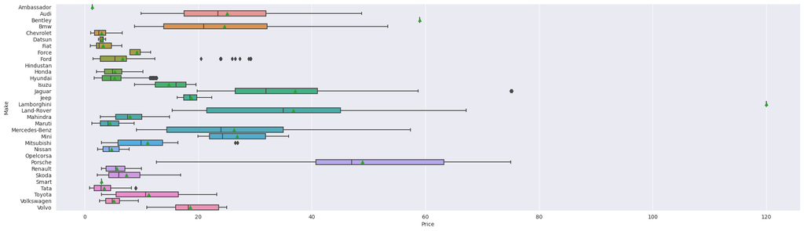

```python
plt.figure(figsize=(25,7))
sns.boxplot(data=df,x='Price', y='Make', showmeans=True,showfliers=True);
```

```python
df.shape
```

```
(7252, 13)
```

**Model**

Let's try to derive model names from the 'Name' column. We will only use this to help us impute missing values.

```python
df['Model'] = df['Name'].str.split(n=1).str[1].str.lower()
# Splitting the column and keeping everything to the left of the first space
df['Model'] = df['Make'] +'_'+ df['Model'].str.split(n=1).str[0]
```

```python
pd.set_option('display.max_rows', 300)
```

```python
model_df = pd.DataFrame(df.groupby(['Make', 'Model']).size())
model_df
```

| Make | Model | 0 |
| --- | --- | --- |
| Ambassador | Ambassador_classic | 1 |
| Audi | Audi_a3 | 6 |
|  | Audi_a4 | 90 |
|  | Audi_a6 | 66 |
|  | Audi_a7 | 3 |
|  | Audi_a8 | 3 |
|  | Audi_q3 | 35 |
|  | Audi_q5 | 38 |
|  | Audi_q7 | 39 |
|  | Audi_rs5 | 2 |
|  | Audi_tt | 3 |
| Bentley | Bentley_continental | 1 |
|  | Bentley_flying | 1 |
| Bmw | Bmw_1 | 3 |
|  | Bmw_3 | 109 |
|  | Bmw_5 | 86 |
|  | Bmw_6 | 9 |
|  | Bmw_7 | 17 |
|  | Bmw_x1 | 36 |
|  | Bmw_x3 | 17 |
|  | Bmw_x5 | 25 |
|  | Bmw_x6 | 8 |
|  | Bmw_z4 | 2 |
| Chevrolet | Chevrolet_aveo | 17 |
|  | Chevrolet_beat | 54 |
|  | Chevrolet_captiva | 3 |
|  | Chevrolet_cruze | 23 |
|  | Chevrolet_enjoy | 13 |
|  | Chevrolet_optra | 13 |
|  | Chevrolet_sail | 10 |

[output cut: 192 more lines]

Most of these look good but we can see that some models are duplicated due to having '-'s.

```python
df['Model'].nunique()
```

```
222
```

```python
# removing
df['Model'] = df['Model'].str.replace('-', '', regex=False)
```

```python
df['Model'].nunique()
```

```
220
```

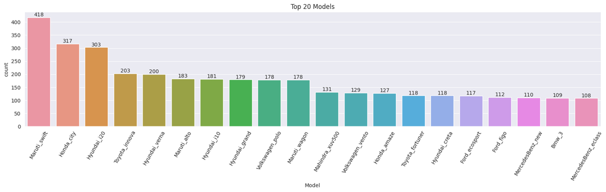

```python
plt.figure(figsize=(20,4))
plt.title('Top 20 Models')
ax = sns.countplot(x='Model', data = df, order = df['Model'].value_counts().iloc[:20].index)
plt.xticks(rotation=60);
ax.bar_label(ax.containers[0], label_type='edge');
```

Instead of using the make name, we will bin them based on class descriptions from used car sites/research.

```python
#creating dictionary with keys as classes and makes as values
class_dict = {
    'Luxury' : ['Bentley', 'Lamborghini'],
    'High-End': ['Audi', 'Mercedes-Benz', 'Bmw', 'Jaguar', 'Porsche', 'Land-Rover'],
    'Mid-Level': ['Honda', 'Toyota', 'Volkswagen', 'Mitsubishi', 'Renault', 'Volvo', 'Chevrolet', 'Skoda', 'Mini', 'Jeep', 'Isuzu','Ford'],
    'Economy': ['Maruti', 'Hyundai', 'Nissan', 'Tata', 'Mahindra', 'Datsun', 'Smart', 'Ambassador', 'Force', 'Fiat']}

# adding class column to df
df['class'] = df['Make'].apply(lambda x: next((class_type for class_type, models in class_dict.items() if x in models), 'Unknown'))
```

## **Handling NaNs**

```python
#creating function that prints count and % of missing values per column if present
def missing_data(df):
    total = df.isnull().sum().sum()
    if total == 0:
        print("No missing values")
    else:
        for col in df.columns:
            count = df[col].isnull().sum()
            if count != 0:
                percent = count / len(df) * 100
                print(f"{col}............: {count} ({percent:.2f}%)")
```

```python
missing_data(df)
```

```
Mileage............: 83 (1.14%)
Engine............: 46 (0.63%)
Power............: 175 (2.41%)
Seats............: 53 (0.73%)
Price............: 1233 (17.00%)
```

We will impute by the model name, if the model name is one-off we will impute by the brand.

```python
#columns with null values
columns_to_fill = ['Power', 'Mileage','Engine','Seats']

#dfs of calculated medians by model and make
model_medians = df.groupby(['Model'])[columns_to_fill].transform('median')
make_medians = df.groupby(['Make'])[columns_to_fill].transform('median')

# filling na's with model
df[columns_to_fill] = df[columns_to_fill].fillna(model_medians)
# filling na's with make
df[columns_to_fill] = df[columns_to_fill].fillna(make_medians)
```

```python
missing_data(df)
```

```
Mileage............: 1 (0.01%)
Power............: 2 (0.03%)
Price............: 1233 (17.00%)
```

We can see that there is still one null value for Mileage. It's because it's the only car by Smart in the set. According to Autocar-India, mileage is ~37.

```python
df[df['Mileage'].isnull()]
```

|  | Name | Location | Year | Kilometers_Driven | Fuel_Type | Transmission | Owner_Type | Mileage | Engine | Power | Seats | Price | Make | Model | class |
| --- | --- | --- | --- | --- | --- | --- | --- | --- | --- | --- | --- | --- | --- | --- | --- |
| 6114 | Smart Fortwo CDI AT | Pune | 2008 | 103000 | Diesel | Automatic | Second | NaN | 799.0 | NaN | 2.0 | 3.0 | Smart | Smart_fortwo | Economy |

```python
df.loc[6114,'Mileage'] = 37
```

```python
missing_data(df)
```

```
Power............: 2 (0.03%)
Price............: 1233 (17.00%)
```

**Power**

```python
df[df['Power'].isnull()]
```

|  | Name | Location | Year | Kilometers_Driven | Fuel_Type | Transmission | Owner_Type | Mileage | Engine | Power | Seats | Price | Make | Model | class |
| --- | --- | --- | --- | --- | --- | --- | --- | --- | --- | --- | --- | --- | --- | --- | --- |
| 1160 | Hindustan Motors Contessa 2.0 DSL | Pune | 1996 | 65000 | Diesel | Manual | Second | 14.1 | 1995.0 | NaN | 5.0 | NaN | Hindustan | Hindustan_motors | Unknown |
| 6114 | Smart Fortwo CDI AT | Pune | 2008 | 103000 | Diesel | Automatic | Second | 37.0 | 799.0 | NaN | 2.0 | 3.0 | Smart | Smart_fortwo | Economy |

According to Autocar-India, bhp is ~45 for the Fortwo and ~102 for the Contessa.

```python
df.loc[6114,'Power'] = 45
df.loc[1160,'Power'] = 102
```

```python
missing_data(df)
```

```
Price............: 1233 (17.00%)
```

We will go ahead and drop rows null 'Price'.

```python
df.dropna(subset=['Price'], inplace=True)
missing_data(df)
```

```
No missing values
```

```python
df.shape
```

```
(6019, 15)
```

```python
df.describe().T
```

|  | count | mean | std | min | 25% | 50% | 75% | max |
| --- | --- | --- | --- | --- | --- | --- | --- | --- |
| Year | 6019.0 | 2013.358199 | 3.269742 | 1998.00 | 2011.00 | 2014.00 | 2016.00 | 2019.0 |
| Kilometers_Driven | 6019.0 | 57667.341253 | 37875.675574 | 171.00 | 34000.00 | 53000.00 | 73000.00 | 775000.0 |
| Mileage | 6019.0 | 18.315016 | 4.172964 | 6.40 | 15.29 | 18.16 | 21.10 | 37.0 |
| Engine | 6019.0 | 1620.220967 | 600.503886 | 72.00 | 1198.00 | 1493.00 | 1984.00 | 5998.0 |
| Power | 6019.0 | 112.657971 | 53.811727 | 34.20 | 74.00 | 93.70 | 138.10 | 560.0 |
| Seats | 6019.0 | 5.277953 | 0.803778 | 2.00 | 5.00 | 5.00 | 5.00 | 10.0 |
| Price | 6019.0 | 9.300119 | 10.426112 | 0.85 | 3.50 | 5.65 | 9.75 | 120.0 |

```python
df.info()
```

```
<class 'pandas.core.frame.DataFrame'>
Int64Index: 6019 entries, 0 to 7244
Data columns (total 15 columns):
 #   Column             Non-Null Count  Dtype
---  ------             --------------  -----
 0   Name               6019 non-null   object
 1   Location           6019 non-null   object
 2   Year               6019 non-null   int64
 3   Kilometers_Driven  6019 non-null   int64
 4   Fuel_Type          6019 non-null   object
 5   Transmission       6019 non-null   object
 6   Owner_Type         6019 non-null   object
 7   Mileage            6019 non-null   float64
 8   Engine             6019 non-null   float64
 9   Power              6019 non-null   float64
 10  Seats              6019 non-null   float64
 11  Price              6019 non-null   float64
 12  Make               6019 non-null   object
 13  Model              6019 non-null   object
 14  class              6019 non-null   object
dtypes: float64(5), int64(2), object(8)
memory usage: 752.4+ KB
```

**Class**

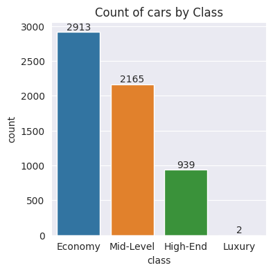

```python
#plotting class counts
plt.figure(figsize=(4,4))
plt.title('Count of cars by Class')
ax = sns.countplot(x='class', data = df, order = df['class'].value_counts().iloc[:4].index)
ax.bar_label(ax.containers[0], label_type='edge');
```

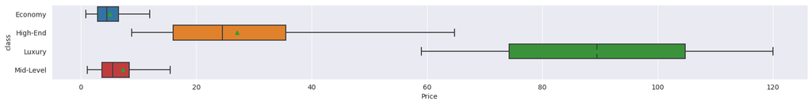

```python
plt.figure(figsize=(20,2))
sns.boxplot(data=df,x='Price', y='class', showmeans=True,showfliers=False);
```

We can see that most cars are considered Economy, least is Luxury.

**Categorical features by class**

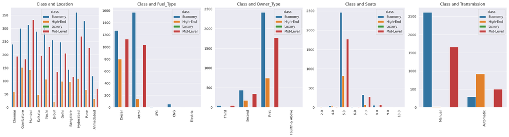

```python
# Create a figure and axis for the subplots
fig, axes = plt.subplots(1, 5, figsize=(22, 6))
# Flatten the 2D array of axes to make it easier to iterate over
axes = axes.flatten()
# Iterate through the categorical columns and plot count plots
for i, cat_col in enumerate(cat_cols):
    sns.countplot(data=df,x=cat_col,hue='class', ax=axes[i])
    axes[i].set_title(f"Class and {cat_col}")
    axes[i].set_xlabel('')
    axes[i].set_ylabel('')
    axes[i].tick_params(axis='x', rotation=90)
# Adjust spacing between subplots
plt.tight_layout();
```

As expected Economy leads most features by count.

- Bangalore and Coimbatore around equal count of high high-end and mid-level cars.
- Most high-end cars are diesel and automatic

```python
#creating df of top 3 cars makes by class
#grouping the data by 'Class' and count the occurrences of each 'Make' within each class
grouped = df.groupby('class')['Make'].value_counts().reset_index(name='Count')
# Sort the counts in descending order for each class
grouped.sort_values(['class', 'Count'], ascending=[True, False], inplace=True)
# getting the top three makes per class
top_three_per_class = pd.DataFrame(grouped.groupby('class').head(3))
top_three_per_class
```

|  | class | Make | Count |
| --- | --- | --- | --- |
| 0 | Economy | Maruti | 1211 |
| 1 | Economy | Hyundai | 1107 |
| 2 | Economy | Mahindra | 272 |
| 10 | High-End | Mercedes-Benz | 318 |
| 11 | High-End | Bmw | 267 |
| 12 | High-End | Audi | 236 |
| 16 | Luxury | Bentley | 1 |
| 17 | Luxury | Lamborghini | 1 |
| 18 | Mid-Level | Honda | 608 |
| 19 | Mid-Level | Toyota | 411 |
| 20 | Mid-Level | Volkswagen | 315 |

- Mercedes-Benz, BMW, & Audi are the top 3 High-End brands by count.
- Honda, Toyota, & Volkswagen are the top 3 Mid-Level brands by count.
- Maruti, Hyundai, & Mahindra are the top 3 Econonmy brands by count.

**Log Transformation**

Earlier we saw in the boxplots that several columns had skewed data. Let's look at those and log transform them.

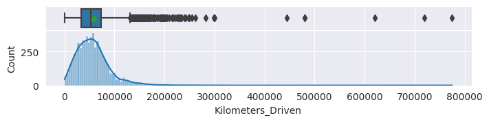

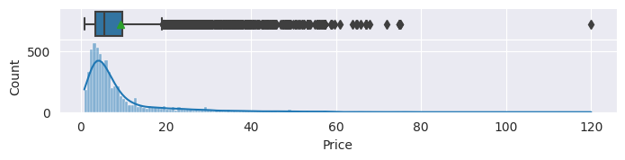

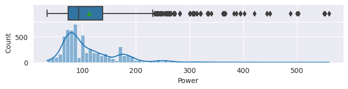

```python
cols = ['Kilometers_Driven','Price','Power']
for column in cols:
  histogram_boxplot(df, column, figsize=(8,1.5), kde=True,color=None)
```

```python
df['price_log'] = np.log(df['Price'])
df['km_log'] = np.log(df['Kilometers_Driven'])
df['power_log'] = np.log(df['Power'])
```

```python
lst = ['Price','price_log','Kilometers_Driven','km_log','Power','power_log']
```

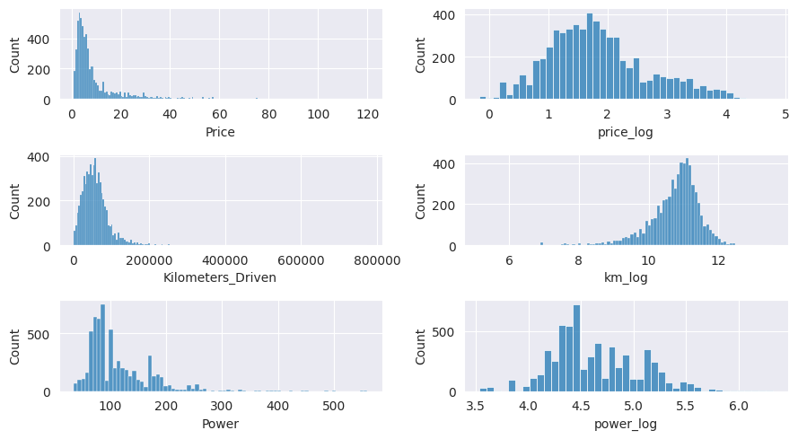

```python
 # Create a figure and axis for the subplots
fig, axes = plt.subplots(3, 2, figsize=(9,5))
# Flatten the 2D array of axes to make it easier to iterate over
axes = axes.flatten()
# Iterate through the categorical columns and plot count plots
for i, col in enumerate(lst):
    sns.histplot(data=df,x=col, ax=axes[i])
# Adjust spacing between subplots
plt.tight_layout();
```

We can see that after log tranformation Price, Power, & Kilometers_Driven are more normally distributed.

## **Building Various Models**

1. What we want to predict is the "Price". We will use the normalized version 'price_log' for modeling.
2. Before we proceed to the model, we'll have to encode categorical features. We will drop categorical features like Name.
3. We'll split the data into train and test, to be able to evaluate the model that we build on the train data.
4. Build Regression models using train data.
5. Evaluate the model performance.

### **Split the Data**

```python
 #converting object data type to category data type
df["Fuel_Type"] = df["Fuel_Type"].astype("category")
df["Transmission"] = df["Transmission"].astype("category")
df["Owner_Type"] = df["Owner_Type"].astype("category")
df["Location"] = df["Location"].astype("category")
df["class"] = df["class"].astype("category")
```

```python
model_df = df.copy()
model_df = model_df.drop(['Name','Kilometers_Driven','Model','Power','Price','Make'],axis=1)
model_df.info()
```

```
<class 'pandas.core.frame.DataFrame'>
Int64Index: 6019 entries, 0 to 7244
Data columns (total 12 columns):
 #   Column        Non-Null Count  Dtype
---  ------        --------------  -----
 0   Location      6019 non-null   category
 1   Year          6019 non-null   int64
 2   Fuel_Type     6019 non-null   category
 3   Transmission  6019 non-null   category
 4   Owner_Type    6019 non-null   category
 5   Mileage       6019 non-null   float64
 6   Engine        6019 non-null   float64
 7   Seats         6019 non-null   float64
 8   class         6019 non-null   category
 9   price_log     6019 non-null   float64
 10  km_log        6019 non-null   float64
 11  power_log     6019 non-null   float64
dtypes: category(5), float64(6), int64(1)
memory usage: 406.7 KB
```

```python
# Splitting the data into features (X) and target (y)
y = model_df["price_log"]
X = model_df.drop(["price_log"], axis=1)
# Encoding categorical features (drop_first=True is used to avoid multicollinearity)
X = pd.get_dummies(X, drop_first=True)

#train test split

X_train, X_test, y_train, y_test = train_test_split(X, y, test_size=0.2, random_state=1)
X_train, X_val, y_train, y_val = train_test_split(X_train, y_train, test_size=0.25, random_state=462)

print(X_train.shape)
print(X_val.shape)
print(X_test.shape)
```

```
(3611, 27)
(1204, 27)
(1204, 27)
```

**Multi-collinearity Check**

```python
#function for vif
def vif(x):
    vifdf = pd.DataFrame()
    x=sm.add_constant(x)
    vifdf["feature"] = x.columns
    # finding vif for each column
    vifdf["VIF"] = [variance_inflation_factor(x.values, i) for i in range(x.shape[1])]
    return vifdf
vif(X_train)
```

|  | feature | VIF |
| --- | --- | --- |
| 0 | const | 861433.656502 |
| 1 | Year | 2.233357 |
| 2 | Mileage | 3.411922 |
| 3 | Engine | 6.657957 |
| 4 | Seats | 1.919275 |
| 5 | km_log | 1.832243 |
| 6 | power_log | 6.180956 |
| 7 | Location_Bangalore | 2.495991 |
| 8 | Location_Chennai | 3.075277 |
| 9 | Location_Coimbatore | 3.535625 |
| 10 | Location_Delhi | 3.235733 |
| 11 | Location_Hyderabad | 3.987848 |
| 12 | Location_Jaipur | 2.581826 |
| 13 | Location_Kochi | 3.654658 |
| 14 | Location_Kolkata | 3.188014 |
| 15 | Location_Mumbai | 4.161656 |
| 16 | Location_Pune | 3.506532 |
| 17 | Fuel_Type_Diesel | 29.367179 |
| 18 | Fuel_Type_Electric | 1.051388 |
| 19 | Fuel_Type_LPG | 1.136646 |
| 20 | Fuel_Type_Petrol | 30.438355 |
| 21 | Transmission_Manual | 2.108999 |
| 22 | Owner_Type_Fourth & Above | 1.016064 |
| 23 | Owner_Type_Second | 1.178665 |
| 24 | Owner_Type_Third | 1.120781 |
| 25 | class_High-End | 3.158776 |
| 26 | class_Luxury | 1.060290 |
| 27 | class_Mid-Level | 1.373914 |

We can see that Engine and power_log are over 5. We will drop Engine, as Power is a more highly correlated feature with Price. We won't need to remove categories within a categorical features.

```python
# Splitting the data into features (X) and target (y)
y = model_df["price_log"]
X = model_df.drop(["price_log","Engine"], axis=1)
# Encoding categorical features (drop_first=True is used to avoid multicollinearity)
X = pd.get_dummies(X, drop_first=True)
#train test split
X_train, X_test, y_train, y_test = train_test_split(X, y, test_size=0.2, random_state=1)
#validation set
X_train, X_val, y_train, y_val = train_test_split(X_train, y_train, test_size=0.25, random_state=462)

print(X_train.shape)
print(X_val.shape)
print(X_test.shape)
```

```
(3611, 26)
(1204, 26)
(1204, 26)
```

```python
vif(X_train)
```

|  | feature | VIF |
| --- | --- | --- |
| 0 | const | 856905.194327 |
| 1 | Year | 2.218395 |
| 2 | Mileage | 2.998236 |
| 3 | Seats | 1.783171 |
| 4 | km_log | 1.829557 |
| 5 | power_log | 3.628334 |
| 6 | Location_Bangalore | 2.495926 |
| 7 | Location_Chennai | 3.074858 |
| 8 | Location_Coimbatore | 3.534932 |
| 9 | Location_Delhi | 3.235728 |
| 10 | Location_Hyderabad | 3.985624 |
| 11 | Location_Jaipur | 2.581650 |
| 12 | Location_Kochi | 3.654602 |
| 13 | Location_Kolkata | 3.187944 |
| 14 | Location_Mumbai | 4.156956 |
| 15 | Location_Pune | 3.506528 |
| 16 | Fuel_Type_Diesel | 29.258529 |
| 17 | Fuel_Type_Electric | 1.045984 |
| 18 | Fuel_Type_LPG | 1.134090 |
| 19 | Fuel_Type_Petrol | 29.730519 |
| 20 | Transmission_Manual | 2.108975 |
| 21 | Owner_Type_Fourth & Above | 1.015529 |
| 22 | Owner_Type_Second | 1.178604 |
| 23 | Owner_Type_Third | 1.120781 |
| 24 | class_High-End | 3.156446 |
| 25 | class_Luxury | 1.023896 |
| 26 | class_Mid-Level | 1.361845 |

We can see that power_log is now beneath 5.

**Scaling Dataset**

```python
scaler = StandardScaler()
X_train = scaler.fit_transform(X_train)
X_test = scaler.transform (X_test)
X_val = scaler.transform(X_val)
```

## Models

We will the following models and see how they perform, for scoring we will look the Root Mean Squared Error. We will tune models as we see fit and we will also look at the models training time.

- Linear Regression
- Lasso Regression
- Ridge Regression
- Decision Tree
- Random Forest
- Excelerated Gradient Boost

```python
#creating function to calculate rmse for train and test sets of given models
def calculate_rmse(models, X_train, y_train, preds, actuals):
    rmse_results = []

    for model in models:
        train_predics = model.predict(X_train)
        train_rmse = np.round(np.sqrt(mean_squared_error(y_train, train_predics)),5)
        test_predics = model.predict(preds)
        test_rmse = np.round(np.sqrt(mean_squared_error(actuals, test_predics)),5)
        # appending RMSE to a list of results
        rmse_results.append({"Model": model.__class__.__name__,"Train_RMSE": train_rmse,"Val_RMSE": test_rmse})
    rmse_df = pd.DataFrame(rmse_results)
    return rmse_df
```

```python
def residual_plots(model,name, features, target):
    # getting preds and calculating avg error
    predictions = model.predict(features)
    actuals = target
    residuals = predictions - actuals
    avg_residual = residuals.mean()
    #creating subplot
    fig, axes = plt.subplots(1, 2, figsize=(8, 5))
    # histogram on the first subplot
    sns.histplot(residuals, kde=True, bins=50,ax=axes[0])
    #residual plot as second subplot
    sns.residplot(x=predictions,y=residuals,lowess=True, scatter_kws={'alpha': 0.5},ax=axes[1])
    fig.suptitle(f'{name} | residual avg: {np.round(avg_residual,6)}', fontsize=16)
    plt.tight_layout();
```

**Linear Regression, Lasso, Ridge**

```python
# creating and training models
linreg = LinearRegression()
lasso = Lasso()
ridge = Ridge()
#fitting models
linreg.fit(X_train, y_train)
lasso.fit(X_train, y_train)
ridge.fit(X_train, y_train)
#creating coefficient df
columns = list(X.columns)
coefficients = linreg.coef_
coef_df = pd.DataFrame({'Feature': columns, 'coeff': coefficients})
coef_df = coef_df.sort_values(by='coeff', ascending=False)
coef_df
```

|  | Feature | coeff |
| --- | --- | --- |
| 4 | power_log | 0.388588 |
| 0 | Year | 0.328562 |
| 23 | class_High-End | 0.236025 |
| 2 | Seats | 0.054406 |
| 9 | Location_Hyderabad | 0.038001 |
| 5 | Location_Bangalore | 0.028811 |
| 7 | Location_Coimbatore | 0.027106 |
| 25 | class_Mid-Level | 0.024443 |
| 24 | class_Luxury | 0.023664 |
| 16 | Fuel_Type_Electric | 0.020096 |
| 15 | Fuel_Type_Diesel | 0.016958 |
| 6 | Location_Chennai | 0.006946 |
| 20 | Owner_Type_Fourth & Above | 0.006309 |
| 17 | Fuel_Type_LPG | -0.006815 |
| 11 | Location_Kochi | -0.007650 |
| 10 | Location_Jaipur | -0.009633 |
| 22 | Owner_Type_Third | -0.009923 |
| 14 | Location_Pune | -0.012871 |
| 8 | Location_Delhi | -0.015460 |
| 13 | Location_Mumbai | -0.022198 |
| 21 | Owner_Type_Second | -0.026125 |
| 19 | Transmission_Manual | -0.052594 |
| 3 | km_log | -0.053425 |
| 1 | Mileage | -0.054890 |
| 12 | Location_Kolkata | -0.074226 |
| 18 | Fuel_Type_Petrol | -0.094550 |

- Power, year(age), cars of brands considered high-end, number if seats, cars in Coimbatore, Hyderabad, and Bangalore, and cars considered Mid-Level and Luxury make up the larger positve coefficients.
- Gas powered cars, cars in Kolkata, gas mileage, kilometers driven, manual cars, and cars with two owners make up the larger negative coefficients.

**Un-tuned linear models results**

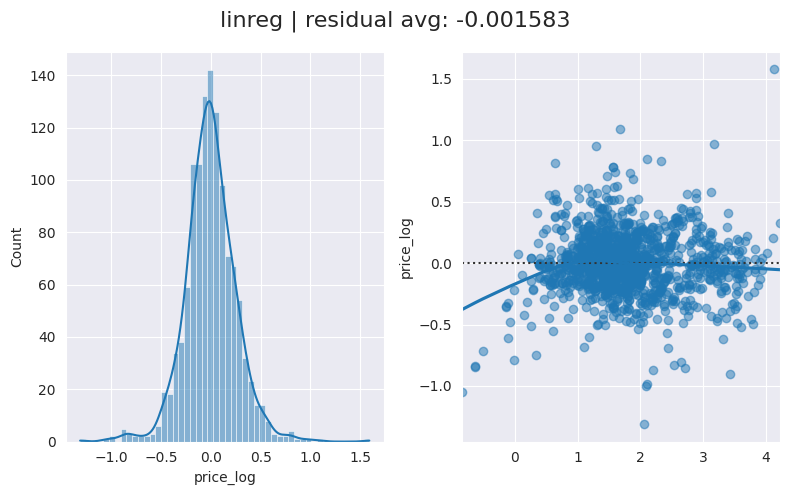

```python
residual_plots(linreg,'linreg', X_val, y_val)
```

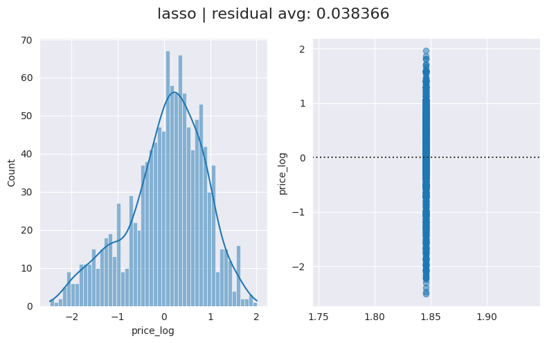

```python
residual_plots(lasso,'lasso', X_val, y_val)
```

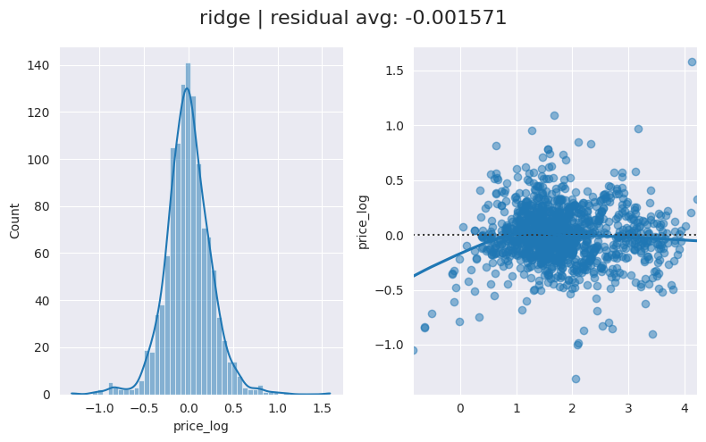

```python
residual_plots(ridge,'ridge', X_val, y_val)
```

```python
#results of the Un-tuned linear models
models = [linreg,ridge,lasso]
calculate_rmse(models, X_train, y_train, X_val, y_val)
```

|  | Model | Train_RMSE | Val_RMSE |
| --- | --- | --- | --- |
| 0 | LinearRegression | 0.25177 | 0.25654 |
| 1 | Ridge | 0.25177 | 0.25653 |
| 2 | Lasso | 0.84455 | 0.84104 |

**Tuning & re-fitting Lasso/Ridge**

```python
#function to perform cv on model, find its best alpha, and refit
def cv_linear_model(model, X_train, y_train, splits=10, random_state=462, score='neg_root_mean_squared_error', param_grid=None):
    if param_grid is None:
        param_grid = {'alpha':[0.001, 0.01, 0.1,.15, 0.2, 0.9, 1, 5, 10, 20,30]}

    folds = KFold(n_splits=splits, shuffle=True, random_state=random_state)
    model_cv = GridSearchCV(estimator=model, param_grid=param_grid, scoring=score, cv=folds, return_train_score=True)
    start = time.time()
    model_cv.fit(X_train, y_train)
    optimal_params = model_cv.best_params_
    tuned_model = model.set_params(**optimal_params)
    tuned_model.fit(X_train, y_train)
    stop = time.time()
    total = np.round(stop - start,2)
    print("Optimal Alpha:", optimal_params)
    print(f"Optimization & Training time: {total}s")
    return tuned_model
```

```python
tuned_lasso = cv_linear_model(Lasso(),X_train, y_train)
```

```
Optimal Alpha: {'alpha': 0.001}
Optimization & Training time: 2.57s
```

```python
tuned_ridge = cv_linear_model(Ridge(),X_train, y_train)
```

```
Optimal Alpha: {'alpha': 5}
Optimization & Training time: 1.3s
```

**Tuned linear models**

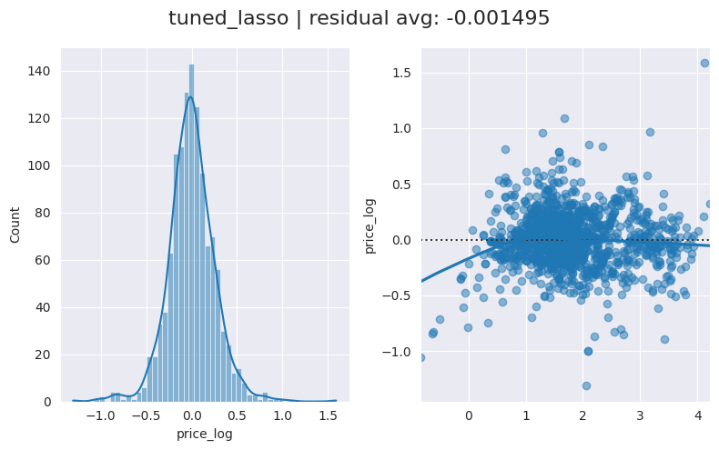

```python
residual_plots(tuned_lasso,'tuned_lasso', X_val, y_val)
```

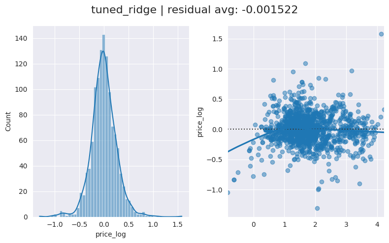

```python
residual_plots(tuned_ridge,'tuned_ridge', X_val, y_val)
```

```python
#results of the tuned linear models
models = [tuned_lasso,tuned_ridge]
calculate_rmse(models, X_train, y_train, X_val, y_val)
```

|  | Model | Train_RMSE | Val_RMSE |
| --- | --- | --- | --- |
| 0 | Lasso | 0.25184 | 0.25667 |
| 1 | Ridge | 0.25177 | 0.25647 |

After tuning lasso performed very similarly to Ridge.

### **Decision Tree, Random Forest, XGBOOST**

**Decision Tree**

```python
# Decision Tree
tree_model = DecisionTreeRegressor(random_state = 462)
# Fitting the model
tree_model.fit(X_train, y_train)

# Random Forest Regressor
forest_model = RandomForestRegressor(n_estimators = 100, random_state = 462)
# Fitting the model
forest_model.fit(X_train, y_train)

# XGBoost Regressor
boost_model = XGBRegressor(random_state = 462)
# Fitting the model
boost_model.fit(X_train,y_train)
```

```
XGBRegressor(base_score=None, booster=None, callbacks=None,
             colsample_bylevel=None, colsample_bynode=None,
             colsample_bytree=None, device=None, early_stopping_rounds=None,
             enable_categorical=False, eval_metric=None, feature_types=None,
             gamma=None, grow_policy=None, importance_type=None,
             interaction_constraints=None, learning_rate=None, max_bin=None,
             max_cat_threshold=None, max_cat_to_onehot=None,
             max_delta_step=None, max_depth=None, max_leaves=None,
             min_child_weight=None, missing=nan, monotone_constraints=None,
             multi_strategy=None, n_estimators=None, n_jobs=None,
             num_parallel_tree=None, random_state=462, ...)
```

```python
def n_features_importance_plot(model,name,top_n=15):
  features = list(X.columns)
  importances = model.feature_importances_
  # Create a DataFrame to store feature names and their importances
  feature_importance_df = pd.DataFrame({'Feature': features, 'Importance': importances})
  feature_importance_df = feature_importance_df.sort_values(by='Importance', ascending=False)
  # Create a bar plot using Seaborn
  plt.figure(figsize=(18, 4))
  ax = sns.barplot(x='Importance', y='Feature', data=feature_importance_df.head(top_n), palette="light:b_r")
  ax.bar_label(ax.containers[0], label_type='edge',fmt='%.2f');
  plt.title(f'{name} | Top {top_n} Features');
```

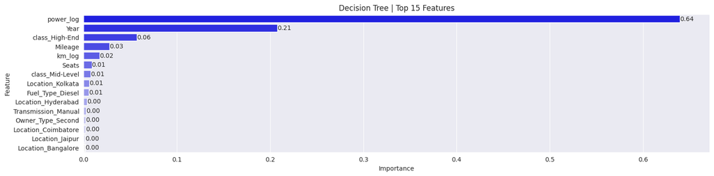

```python
n_features_importance_plot(tree_model,'Decision Tree',top_n=15)
```

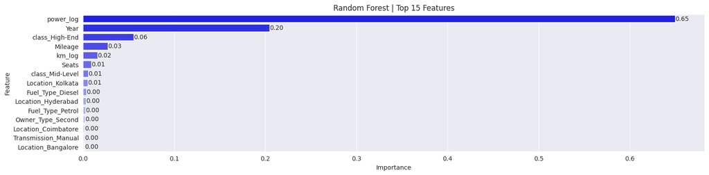

```python
n_features_importance_plot(forest_model,'Random Forest')
```

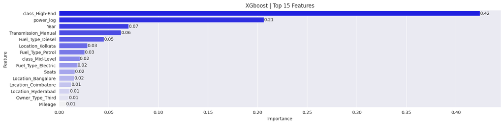

```python
n_features_importance_plot(boost_model,'XGboost')
```

```python
models = [tree_model,forest_model,boost_model]
calculate_rmse(models, X_train, y_train, X_val, y_val)
```

|  | Model | Train_RMSE | Val_RMSE |
| --- | --- | --- | --- |
| 0 | DecisionTreeRegressor | 0.00142 | 0.28242 |
| 1 | RandomForestRegressor | 0.07871 | 0.20863 |
| 2 | XGBRegressor | 0.06683 | 0.19894 |

- We can see that the top three features by each model consist of Power, Year, and High-End cars.
- Each model appears to be overfitting to a certain degree, however the Decision Tree has a much larger disparity between the test and train set and is performing worse than Linear, Ridge, & Lasso.
- Our Random Forest and XGBoost are performing well compared to linear regression. We will tune them and see what changes.